# Supplement

Technical Note: Curve fitting algorithm for multimodal particle size distributions – a theoretical basis

2025-08-25

Christopher N. Rapp<sup>1</sup>, Sining Niu<sup>2</sup>, Yue Zhang<sup>2</sup>, A. Gannet Hallar<sup>3</sup>, Fred J. Brechtel<sup>4</sup>, and Daniel J. Cziczo<sup>1</sup>

<sup>1</sup>Department of Earth, Atmospheric, and Planetary Sciences, Purdue University, West Lafayette, Indiana, 47906-2051, USA

<sup>2</sup>Department of Atmospheric Sciences, Texas A&M University, College Station, Texas, 77843-3150, USA

<sup>3</sup>Department of Atmospheric Sciences, University of Utah, Salt Lake City, Utah, 84112-0102, USA

<sup>4</sup>Brechtel Manufacturing Incorporated, Hayward, California, 94544, USA

*Correspondence to*: Christopher N. Rapp (christopherrapp@icloud.com)

Source code for SMPS read functions are housed here https://github.com/christopher-rapp/scripts-multimodal.git

# Setup

## Import Libraries

```r
library(stringr)
library(data.table)
library(tidyr)
library(dplyr)
library(lubridate)
library(logr)
library(ggplot2)
library(purrr)
library(patchwork)
library(ncdf4)
```

## User Paths

To download the example data visit

https://github.com/christopher-rapp/scripts-multimodal/tree/main/examples

```r
log.path = '~/Library/CloudStorage/Box-Box/Multimodal Curve Fitting/log/'

import.path.BMI = '~/Library/CloudStorage/Box-Box/Multimodal Curve Fitting/example/BMI/'
import.path.TSI = '~/Library/CloudStorage/Box-Box/Multimodal Curve Fitting/example/TSI/'
import.path.NC = '~/Library/CloudStorage/Box-Box/Multimodal Curve Fitting/example/netCDF/'
import.path.NAS = '~/Library/CloudStorage/Box-Box/Multimodal Curve Fitting/example/NASA-AMES/'
```

# Formatting Data

## Brechtel Manufacturing Inc. (BMI) Data

```r
BMI.data.ls <- readPSD_BMI(import.path.BMI, tz = "US/Eastern")

# Read functions export data as a list to account for multiple files in a directory
dataPSD.BMI <- BMI.data.ls[[1]]

head(dataPSD.BMI)
```

```
##             Local Time            UTC Time #StartDate    StartTime EndDate
##                 <POSc>              <POSc>      <int>       <char>   <int>
## 1: 2023-10-31 18:15:23 2023-10-31 22:15:23     231031 18:15:23.757  231031
## 2: 2023-10-31 18:17:47 2023-10-31 22:17:47     231031 18:17:47.862  231031
## 3: 2023-10-31 18:20:11 2023-10-31 22:20:11     231031 18:20:11.965  231031
## 4: 2023-10-31 18:22:36 2023-10-31 22:22:36     231031 18:22:36.078  231031
## 5: 2023-10-31 18:25:00 2023-10-31 22:25:00     231031 18:25:00.193  231031
## 6: 2023-10-31 18:27:24 2023-10-31 22:27:24     231031 18:27:24.307  231031
##         EndTime StartSecs EndSecs Temp(K) Press(hPa) NumBins   10.16   10.49
##          <char>     <int>   <int>   <num>      <num>   <int>   <num>   <num>
## 1: 18:17:23.748        21     141  26.490    950.521     120 3420.58 3734.03
## 2: 18:19:47.858       165     285  26.466    950.415     120 3159.37 3015.60
## 3: 18:22:11.968       309     429  26.455    950.511     120 7291.97 8002.41
## 4: 18:24:36.083       453     573  26.435    950.417     120 7145.41 7368.59
## 5: 18:27:00.195       597     717  26.412    950.458     120 7046.85 7546.17
```

[output cut: 121 more lines]

## TSI Data

Use example data from Storm Peak Laboratory for a new particle formation event (NPF) on 2022-03-23 MDT.

```r
TSI.data.ls <- readPSD_TSI(import.path.TSI, tz = "US/Mountain")

# Read functions export data as a list to account for multiple files in a directory
dataPSD.TSI <- TSI.data.ls[[1]]

head(dataPSD.TSI)
```

```
##             Local Time            UTC Time Sample #     Date Start Time
##                 <POSc>              <POSc>    <int>   <char>     <char>
## 1: 2022-03-23 00:03:41 2022-03-23 06:03:41    22042 03/23/22   00:03:41
## 2: 2022-03-23 00:08:40 2022-03-23 06:08:40    22043 03/23/22   00:08:40
## 3: 2022-03-23 00:13:40 2022-03-23 06:13:40    22044 03/23/22   00:13:40
## 4: 2022-03-23 00:18:41 2022-03-23 06:18:41    22045 03/23/22   00:18:41
## 5: 2022-03-23 00:23:41 2022-03-23 06:23:41    22046 03/23/22   00:23:41
## 6: 2022-03-23 00:28:41 2022-03-23 06:28:41    22047 03/23/22   00:28:41
##    Sample Temp(C) Sample Pressure(kPa) Mean Free Path(m) Gas Viscosity(Pa*s)
##             <num>                <num>             <num>               <num>
## 1:           21.8                 65.0      1.042800e-07        1.826716e-05
## 2:           21.8                 64.9      1.044406e-07        1.826716e-05
## 3:           21.7                 65.0      1.042511e-07        1.826237e-05
## 4:           21.8                 65.0      1.042961e-07        1.826716e-05
## 5:           21.6                 65.0      1.042061e-07        1.825759e-05
```

[output cut: 137 more lines]

## netCDF Data

Data were obtained from the Atmospheric Radiation Measurement (ARM) User Facility, a U.S. Department of Energy (DOE) Office of Science user facility managed by the Biological and Environmental Research Program.

SGP SMPS data were obtained from the Atmospheric Radiation Measurement (ARM) User Facility, a U.S. Department of Energy (DOE) Office of Science user facility managed by the Biological and Environmental Research Program.

Kuang, C., Singh, A., Howie, J., Salwen, C., & Hayes, C. Scanning mobility particle sizer (AOSSMPS), 2016-11-15 to 2025-06-23, Southern Great Plains (SGP), Lamont, OK (Extended and Co-located with C1) (E13). Atmospheric Radiation Measurement (ARM) User Facility. https://doi.org/10.5439/1476898

```r
NC.data.ls <- readPSD_NC(import.path.NC)

# Read functions export data as a list to account for multiple files in a directory
dataPSD.NC <- NC.data.ls[[1]]

head(dataPSD.NC)
```

```
##                  Time   10.55    10.9    11.3   11.75    12.2    12.65    13.1
## 1 2023-07-19 00:00:01 229.408 548.848 262.211 884.073 530.819  794.500 763.913
## 2 2023-07-19 00:05:00 114.746 299.476 218.582 461.397 597.981  531.017 921.694
## 3 2023-07-19 00:10:00 230.551 451.271 526.986 502.107 579.764  938.770 849.747
## 4 2023-07-19 00:15:00 115.809 352.599 397.037 310.385 445.339 1003.796 908.580
## 5 2023-07-19 00:20:00 114.704 249.476 305.913 768.758 543.062  753.482 818.479
## 6 2023-07-19 00:25:00 347.944 353.094 309.220 388.476 411.583  639.520 854.460
##      13.55    14.05     14.6    15.15     15.7    16.25    16.85     17.5
## 1 1121.157 1130.514 1211.083 1389.714 1453.444 1709.798 1621.780 1876.027
## 2  736.839 1214.537 1172.016 1166.224 1471.679 1399.218 1331.886 1919.116
## 3  964.090  993.853 1014.759 1132.285 1231.431 1539.507 1618.466 1654.262
## 4 1106.781 1338.346 1124.499 1145.662 1598.000 1301.520 1320.362 1795.484
## 5  682.445 1086.181  929.296 1274.957 1257.640 1441.239 1507.432 1662.602
## 6  738.635 1046.237  923.729 1389.188 1166.476 1297.628 1539.155 1552.144
##       18.1    18.75    19.45    20.15     20.9     21.7     22.5     23.3
```

[output cut: 83 more lines]

## NASA-AMES Data

Data obtained from https://ebas-data.nilu.no/DataSets.aspx?stations=US9050R&InstrumentTypes=smps&fromDate=1970-01-01&toDate=2025-12-31.

The EBAS database has largely been funded by the UN-ECE CLRTAP (EMEP), AMAP and through NILU internal resources. Specific developments have been possible due to projects like EUSAAR (EU-FP5)(EBAS web interface), EBAS-Online (Norwegian Research Council INFRA) (upgrading of database platform) and HTAP (European Commission DG-ENV)(import and export routines to build a secondary repository in support of [**www.htap.org**](http://www.htap.org/)). A large number of specific projects have supported development of data and meta data reporting schemes in dialog with data providers (EU)(CREATE, ACTRIS and others).

```r
NAS.data.ls <- readPSD_NAS(import.path.NAS)

# Read functions export data as a list to account for multiple files in a directory
dataPSD.NAS <- NAS.data.ls[[1]]

head(dataPSD.NAS)
```

```
##             starttime             endtime pressure (hPa) temperature (K)   9.14
## 1 2022-03-22 00:00:00 2022-03-22 01:00:00         646.33          299.72 474.24
## 2 2022-03-22 01:00:00 2022-03-22 01:59:59         646.83          299.25  84.12
## 3 2022-03-22 01:59:59 2022-03-22 03:00:00         646.58          298.76   0.00
## 4 2022-03-22 03:00:00 2022-03-22 04:00:00         647.00          298.46   0.00
## 5 2022-03-22 04:00:00 2022-03-22 04:59:59         646.83          298.20   0.00
## 6 2022-03-22 04:59:59 2022-03-22 06:00:00         647.08          297.82   0.00
##     9.47    9.82    10.2    10.6    10.9    11.3    11.8    12.2    12.6
## 1 957.28 2867.13 3583.47 5114.35 6310.64 7191.34 7549.04 8580.99 8822.77
## 2 298.20  916.45 1245.15 1485.14 2468.77 2897.71 3331.94 3617.07 4289.60
## 3 120.74  189.00  529.25  605.65  796.45 1144.47 1584.89 1746.31 2045.49
## 4   0.00   94.34  133.73   75.24  198.43  312.59  320.85  275.00  400.82
## 5   0.00   31.36   25.14   40.92  168.13  238.74  299.34  346.10  351.32
## 6   0.00    0.00   25.07  122.19  151.01  210.47  278.15  342.93  542.03
##      13.1    13.6    14.1    14.6    15.1    15.7    16.3    16.8    17.5
```

[output cut: 69 more lines]

# Running multimodal

Let’s run multimodal on an example dataset using a Brechtel SEMS (Model 2002). Note the log path will need to be changed to whatever location you’d like it sent to!

## Example 1 - Laboratory Data

```r
# Frequency is null here because I already grouped data above
# I've also removed the argument for the log.path which will default to a temporary directory created by R which is deleted upon exiting an R session
result <- multimodal.fitting(dataPSD.BMI,
                             frequency = NULL,
                             labeling = T,
                             max.iterations = 20,
                             max.modes = 6,
                             lower.limit = 10,
                             upper.limit = 1500,
                             NMRSE.threshold = 0.05,
                             FVU.threshold = 20,
                             verbose = T)
```

```
## [1] "Log Path: /var/folders/2j/rmf9p1l50wg904hz8qkpvc4m0000gn/T//RtmpCskXGC/multimodal20231031181523_20250825122533.log"
## [1] "Current Dataset Time: 2023-10-31 22:15:23 UTC"
## [1] "Dataset sampling frequency is 2.4 min"
## [1] "2023-10-31 22:15:23: Current Loop Iteration: 1, Remaining Variance: 94.93%, Number of Modes: 1"
## [1] "2023-10-31 22:15:23: Current Loop Iteration: 2, Remaining Variance: 3.93%, Number of Modes: 2"
## [1] "2023-10-31 22:15:23: Current Loop Iteration: 3, Remaining Variance: 2.57%, Number of Modes: 3"
## [1] "2023-10-31 22:15:23: Current Loop Iteration: 4, Remaining Variance: 1.63%, Number of Modes: 4"
## [1] "2023-10-31 22:15:23: Current Loop Iteration: 5, Remaining Variance: 1.34%, Number of Modes: 5"
## [1] "2023-10-31 22:15:23: Current Loop Iteration: 6, Remaining Variance: 1.3%, Number of Modes: 6"
## [1] "Concentration RMSE: 2132.57 n/cc"
```

```r
# As there is only 1 data file for this set, we will flatten the list

result <- flatten(result)
```

## Outputs

The first element of result is a pass flag i.e. T or F

```r
result$pass
```

```
## [1] TRUE
```

The second is the plot which consists of three panels

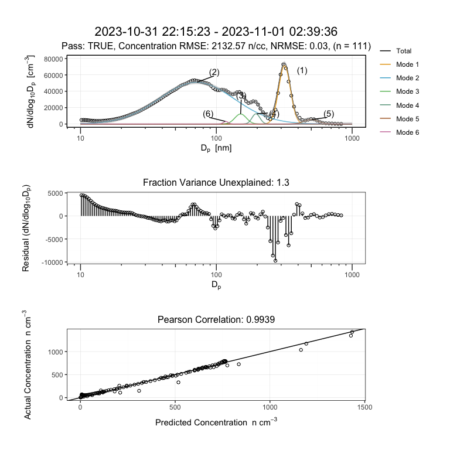

The remaining outputs are predicted data, the data used to plot curves, and evaluation parameters

```r
head(result[[3]])
```

```
##      Dp Predicted dNdlogDp Predicted dN Actual dNdlogDp Actual dN
## 1 10.16             453.91     6.301079        4952.512  68.74969
## 2 10.49             529.09     7.117198        4985.419  67.06273
## 3 10.82             612.31     8.465744        4903.316  67.79281
## 4 11.17             709.75     9.777611        4740.169  65.30121
## 5 11.53             820.21    11.251357        4507.124  61.82717
## 6 11.90             944.94    12.899759        4250.884  58.03054
##   Residual dNdlogDp Residual dN      Ratio
## 1          4498.602    62.44861 0.09165247
## 2          4456.329    59.94553 0.10612748
## 3          4291.006    59.32707 0.12487672
## 4          4030.419    55.52360 0.14973093
## 5          3686.914    50.57581 0.18198080
## 6          3305.944    45.13078 0.22229260
```

```r
head(result[[4]])
```

```
##      Dp Mode 1 Mode 2 Mode 3 Mode 4 Mode 5 Mode 6 dNdlogDp
## 1 10.00      0 420.26      0      0      0      0   420.26
## 2 10.01      0 422.31      0      0      0      0   422.31
## 3 10.02      0 424.37      0      0      0      0   424.37
## 4 10.03      0 426.43      0      0      0      0   426.43
## 5 10.04      0 428.50      0      0      0      0   428.50
## 6 10.05      0 430.58      0      0      0      0   430.58
```

```r
head(result[[5]])
```

```
##   Mode Label          N      GSD       Dpg       Max   Mode  Lower  Upper Width
## 1     Mode 1  7709.7021 1.104493 317.61847 72801.737 311.03 249.85 451.56    13
## 2     Mode 2 35219.1406 1.888153  71.61388 53335.797  69.18  13.51 105.61    62
## 3     Mode 3  1299.9919 1.102360 150.90879 12544.712 147.69 126.94 172.59     8
## 4     Mode 4   906.6612 1.069269 195.75567 12079.366 194.62 165.93 272.39    12
## 5     Mode 5   715.3382 1.128914 499.31587  5631.458 497.83 430.34 830.76    13
## 6     Mode 6   140.9658 1.042290 117.38486  2934.445 117.86  98.26 136.85     9
##         BIC       RSS         TSS        R2 N T pval GSD T pval Dpg T pval
## 1  276.9295 150254441  8174258916 0.9816186    5e-12    2.3e-22   2.16e-22
## 2 1087.2011  88575112 19969539592 0.9955645    1e-65    1.1e-75   1.16e-73
## 3  152.9817   4783910    93721539 0.9489561    8e-07    2.7e-12   1.13e-12
## 4  262.9294 210120965   618259998 0.6601414    4e-03    3.1e-13   3.04e-13
## 5  212.3369   1489699    53034863 0.9719109    2e-10    2.0e-19   5.82e-20
## 6  179.0575  13928215    32875106 0.5763294    4e-02    2.1e-10   2.12e-10
```

```r
result[[6]]
```

```
##      Pearson Correlation    RMSE      NRMSE dN RMSE   dN NRMSE Students T Test
## [1,]              0.9939 2132.57 0.02935411   37.15 0.02613263          0.8524
##      Chi-Squared
## [1,]      0.2391
```

## Example 2 - Storm Peak Laboratory

```
## [1] "Log Path: ~/Library/CloudStorage/Box-Box/Multimodal Curve Fitting/log//multimodal20220323020341_20250825122536.log"
## [1] "Current Dataset Time: 2022-03-23 06:03:41 UTC"
## [1] "Dataset sampling frequency is 5 min"
## [1] "2022-03-23 06:03:41: Error, please modify lower and upper limits to accommadate data set"
```

Notice the failure message? This is because the dataset begins for bin diameter 9.14. Now we can retry with adjusted limits.

```
## [1] "Log Path: ~/Library/CloudStorage/Box-Box/Multimodal Curve Fitting/log//multimodal20220323020341_20250825122536.log"
## [1] "Current Dataset Time: 2022-03-23 06:03:41 UTC"
## [1] "Dataset sampling frequency is 5 min"
## [1] "2022-03-23 06:03:41: Current Loop Iteration: 1, Remaining Variance: 1.11%, Number of Modes: 1"
## [1] "2022-03-23 06:03:41: Current Loop Iteration: 2, Remaining Variance: 0.82%, Number of Modes: 2"
## [1] "Concentration RMSE: 354.11 n/cc"
```

For this file there is a NPF event, but currently the averaging across the entire day removes all temporal variation. We will instead select times between 07:00 and 15:00 and use an hourly frequency.

```
## [1] "Log Path: ~/Library/CloudStorage/Box-Box/Multimodal Curve Fitting/log//multimodal20220323070340_20250825122536.log"
```

```
## $`2022-03-23 11:00:00`
```

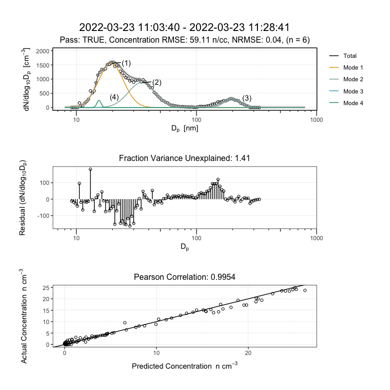

```
##
## $`2022-03-23 12:00:00`
```

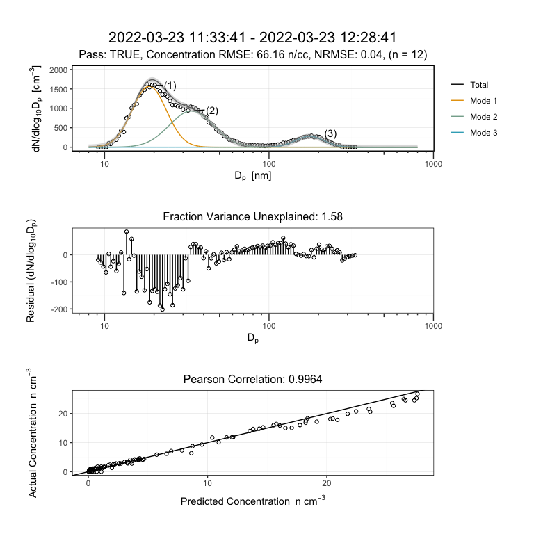

```
##
## $`2022-03-23 13:00:00`
```

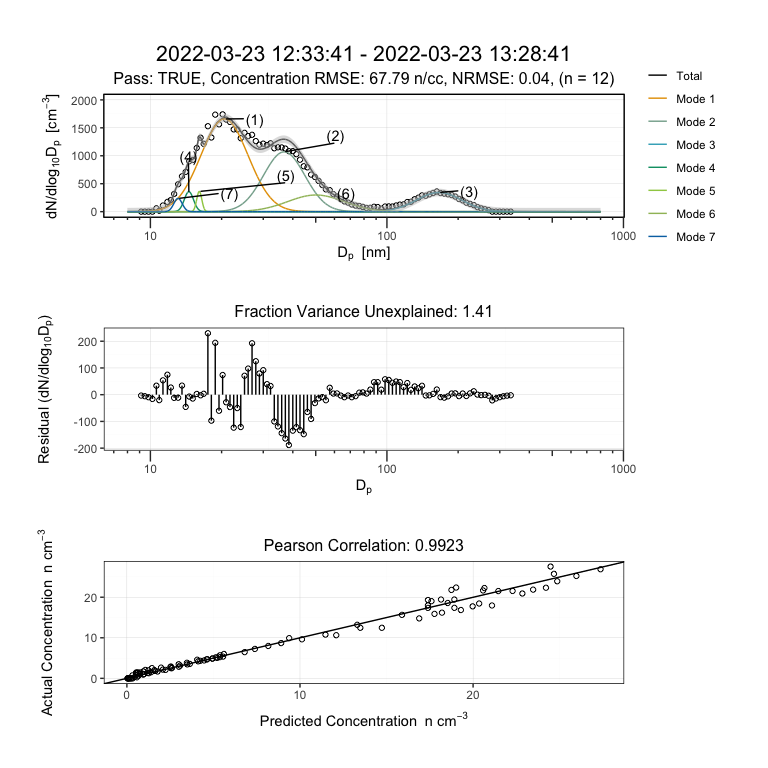

```
##
## $`2022-03-23 14:00:00`
```

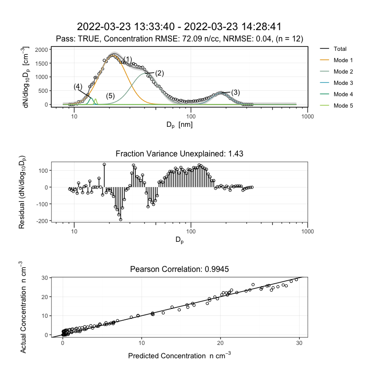

```
##
## $`2022-03-23 15:00:00`
```

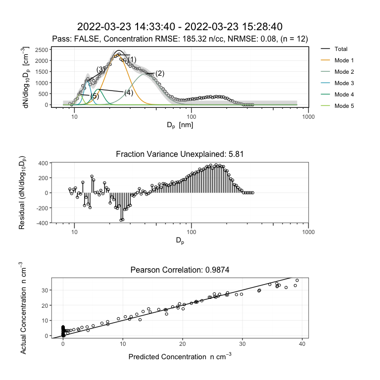

```
##
## $`2022-03-23 16:00:00`
```

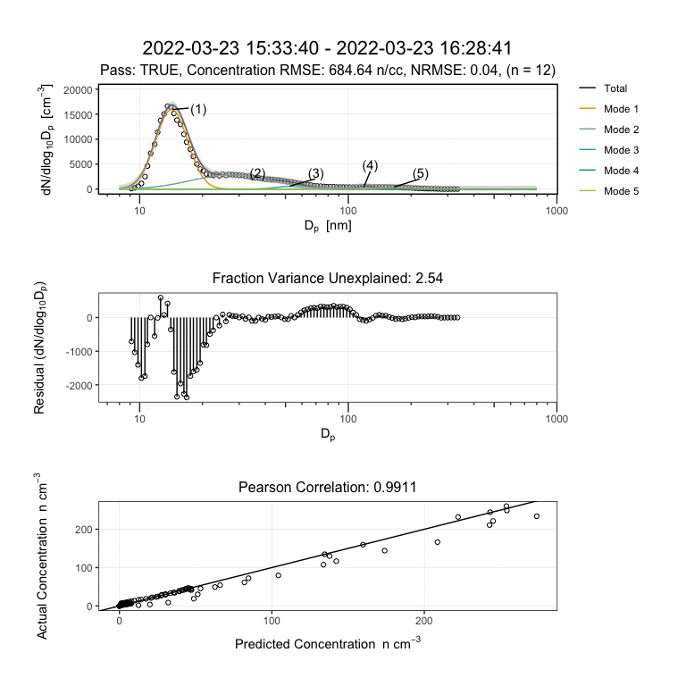

```
##
## $`2022-03-23 17:00:00`
```

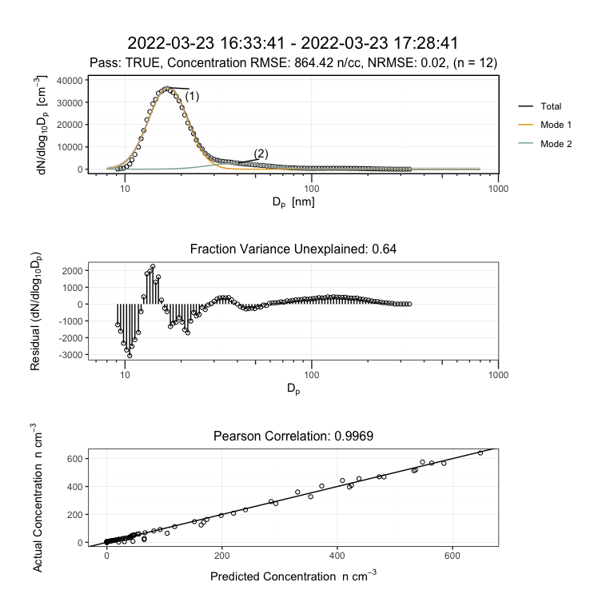

```
##
## $`2022-03-23 18:00:00`
```

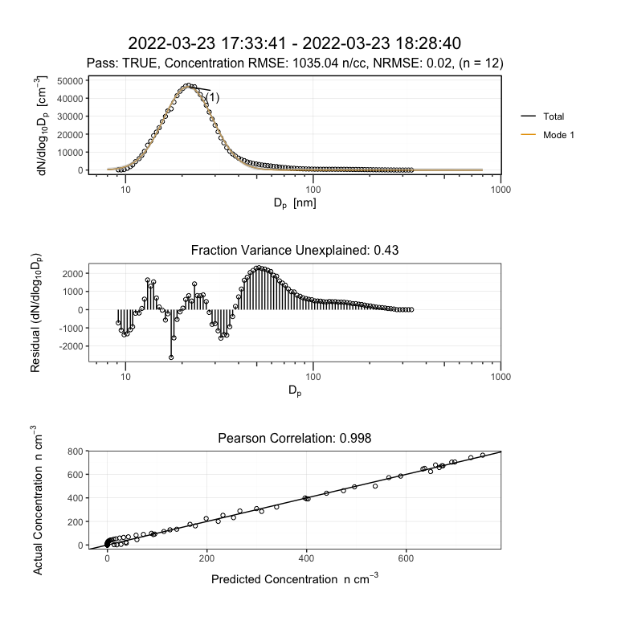

```
##
## $`2022-03-23 19:00:00`
```

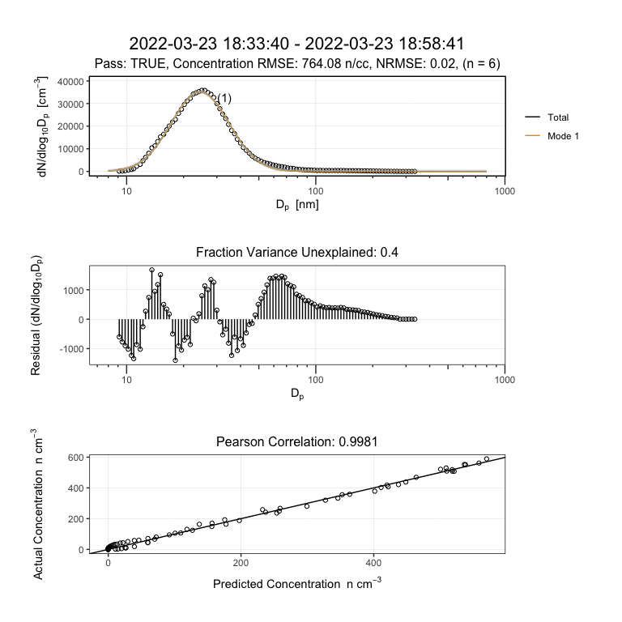

Note - for higher resolution scans, the variation within the scan may be too high to capture. The following is an example.

```
## [1] "Log Path: ~/Library/CloudStorage/Box-Box/Multimodal Curve Fitting/log//multimodal20220323100340_20250825122549.log"
```

```
## $`2022-03-23 14:05:00`
```

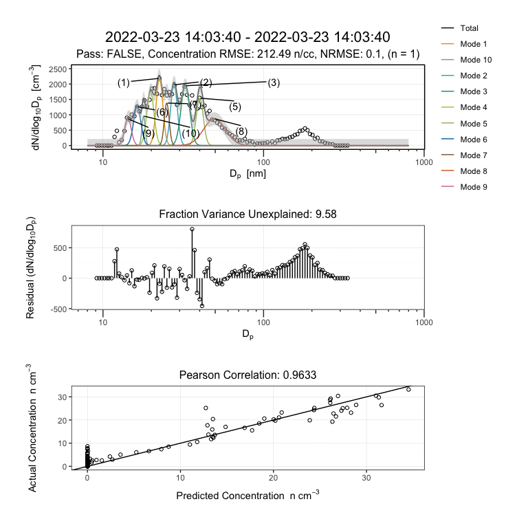